# HW-4: Text classification with RNN

In this assignment we will create a labeled dataset from a corpus of novels.

We will then use this data to train recurrent neural networks for text classification.

**Software**: You can use pytorch OR Keras, however, Keras is recommended since various relevant examples are included in Chapter-6 of the textbook and in the shared codes folder.

**Submission:**

- You need to upload ONE document to Canvas when you are done
  - (1) A PDF (or HTML) of the completed form of this notebook
  - DO NOT UPLOAD THE RAW TEXT DATA, JUST THE COMPLETED NOTEBOOK
- The final uploaded version should NOT have any code-errors present
- All outputs must be visible in the uploaded version, including code-cell outputs, images, graphs, etc
- **Total points:** 41.66

## Data Collection

- Create a labeled corpus of novels by doing ONE of the following
  - Option-1: (title-prediction) Select and download at least 5 novels from project Gutenberg (label=title)
  - Option-2: (author-prediction) Select and download at least 5 novels from project Gutenberg with different authors (label=author)
  - **Note**: You can also be creative and come up with a different labeling method (e.g. genre)
  - **Note**: You can also use the Harry Potter novels (or any other plain-text novels you can find) instead of project Gutenberg
    - https://github.com/formcept/whiteboard/tree/master/nbviewer/notebooks/data/harrypotter
  - Store the plain-text files in a logical way in a folder "./data/" (do not upload for submission)

### HW-4.1.1 Data cleaning and preparation

- Write a code to ingest, clean, and break the novels into chunks of text, either sentences or paragraphs (each with the relevant label)
  - You can recycle the relevant codes from previous assignments
  - You can do this is an different `.ipynb` file if you want, however, make sure to upload it to Canvas if you do!
- Convert this into a dataset suitable for RNN analysis,
- Vectorize the text: Either by (any option is fine)
  - (1) Doing word-embedding with Gensim as a pre-processing step
  - (2) using one-hot-encoding
  - (3) By training an embedding layer with Keras as the first layer of your model
  - Make sure to retain the sequential nature of the text when you vectorize.
  - Feel free to do it differently than the textbook if you prefer
- When debugging and proto-typing, don’t use the entire novel (start small and scale up)
- The final result should be a saved file with the processed-vectorized data ready for analysis
- Document your process using markdown between code cells to help external collaborators understand what you are doing.

```python
import pandas as pd
import os
import glob

files = glob.glob("/Users/yihuiliu_/Desktop/590DeepLearning/hw4/data/*.txt")
path = r'/Users/yihuiliu_/Desktop/590DeepLearning/hw4/data'
os.chdir(path)
texts = []
for file in files:
    with open(file, 'r') as f:
        lines = f.readlines()
    text = ''.join(line for line in lines)
    text = text.replace('\n', ' ')
    text = text.replace('\r', ' ')
    text = text.replace('  ', ' ')
    texts.append(text)
```

```python
len(texts)
```

```
5
```

```python
import nltk
text = ''.join(str(e) for e in texts)
sen = nltk.tokenize.sent_tokenize(text)
```

```python
import re
import spacy
from spacy.language import Language


pipeline = spacy.load('en_core_web_sm')

# http://emailregex.com/
email_re = r"""(?:[a-z0-9!#$%&'*+/=?^_`{|}~-]+(?:\.[a-z0-9!#$%&'*+/=?^_`{|}~-]+)*|"(?:[\x01-\x08\x0b\x0c\x0e-\x1f\x21\x23-\x5b\x5d-\x7f]|\\[\x01-\x09\x0b\x0c\x0e-\x7f])*")@(?:(?:[a-z0-9](?:[a-z0-9-]*[a-z0-9])?\.)+[a-z0-9](?:[a-z0-9-]*[a-z0-9])?|\[(?:(?:25[0-5]|2[0-4][0-9]|[01]?[0-9][0-9]?)\.){3}(?:25[0-5]|2[0-4][0-9]|[01]?[0-9][0-9]?|[a-z0-9-]*[a-z0-9]:(?:[\x01-\x08\x0b\x0c\x0e-\x1f\x21-\x5a\x53-\x7f]|\\[\x01-\x09\x0b\x0c\x0e-\x7f])+)\])"""

# replace = [ (pattern-to-replace, replacement),  ...]
replace = [
    (r"<a[^>]*>(.*?)</a>", r"\1"),  # Matches most URLs
    (email_re, "email"),            # Matches emails
    (r"(?<=\d),(?=\d)", ""),        # Remove commas in numbers
    (r"\d+", "number"),              # Map digits to special token <numbr>
    (r"[\t\n\r\*\.\@\,\-\/]", " "), # Punctuation and other junk
    (r"\s+", " ")                   # Stips extra whitespace
]
```

```python
for repl in replace:
    sen_clean = [re.sub(repl[0], repl[1], text) for text in sen]
```

```python
len(sen_clean)
```

```
41972
```

```python
n = 5 # chunk length
inputs = [sen[i:i+n] for i in range(0, len(sen_clean), n)]
```

```python
import re
import pandas as pd

punc_ul = r"""(?:[a-z0-9!#$%&'*+/=?^_`{|}~-]+(?:\.[a-z0-9!#$%&'*+/=?^_`{|}~-]+)*|"(?:[\x01-\x08\x0b\x0c\x0e-\x1f\x21\x23-\x5b\x5d-\x7f]|\\[\x01-\x09\x0b\x0c\x0e-\x7f])*")@(?:(?:[a-z0-9](?:[a-z0-9-]*[a-z0-9])?\.)+[a-z0-9](?:[a-z0-9-]*[a-z0-9])?|\[(?:(?:25[0-5]|2[0-4][0-9]|[01]?[0-9][0-9]?)\.){3}(?:25[0-5]|2[0-4][0-9]|[01]?[0-9][0-9]?|[a-z0-9-]*[a-z0-9]:(?:[\x01-\x08\x0b\x0c\x0e-\x1f\x21-\x5a\x53-\x7f]|\\[\x01-\x09\x0b\x0c\x0e-\x7f])+)\])"""

for i in range(len(inputs)):
    sen = ''.join(inputs[i])
    sen_n = re.sub(r'[^\w\s]','',sen)
    sen_n = re.sub(punc_ul,'',sen_n)
    sen_n = re.sub(r'\w*\d\w*','',sen_n)
    inputs[i] = sen_n

df_all = pd.DataFrame({'content':inputs})
```

```python
df_all.head()
```

|  | content |
| --- | --- |
| 0 | OWL POST Harry Potter was a highly unusual... |
| 1 | Harry moved the tip of his eaglefeather quill ... |
| 2 | Harry put his quill between his teeth and reac... |
| 3 | Harrys dead parents who had been a witch and w... |
| 4 | This separation from his spellbooks had been a... |

```python
len(df_all)
```

```
8395
```

```python
titles = [[title]*len(inputs[i]) for i, title in enumerate(files)]
```

```python
for filename in files:
    print(filename)
```

```
/Users/yihuiliu_/Desktop/590DeepLearning/hw4/data/Book 3 - The Prisoner of Azkaban.txt
/Users/yihuiliu_/Desktop/590DeepLearning/hw4/data/Book 2 - The Chamber of Secrets.txt
/Users/yihuiliu_/Desktop/590DeepLearning/hw4/data/Book 4 - The Goblet of Fire.txt
/Users/yihuiliu_/Desktop/590DeepLearning/hw4/data/Book 1 - The Philosopher's Stone.txt
/Users/yihuiliu_/Desktop/590DeepLearning/hw4/data/Book 5 - The Order of the Phoenix.txt
```

```python
labels = ["The Philosopher's Stone"]*1679 + ['The Chamber of Secrets']*1679 + ['The Prisoner of Azkaban']*1679 + ['The Goblet of Fire']*1679 + ['The Order of the Phoenix']*1679
```

```python
df_all['label'] = labels
df_all.head()
```

|  | content | label |
| --- | --- | --- |
| 0 | OWL POST Harry Potter was a highly unusual... | The Philosopher's Stone |
| 1 | Harry moved the tip of his eaglefeather quill ... | The Philosopher's Stone |
| 2 | Harry put his quill between his teeth and reac... | The Philosopher's Stone |
| 3 | Harrys dead parents who had been a witch and w... | The Philosopher's Stone |
| 4 | This separation from his spellbooks had been a... | The Philosopher's Stone |

```python
data = df_all['content']
labels = df_all['label']
from sklearn.model_selection import train_test_split
x_train, x_test, y_train, y_test = train_test_split(data, labels, test_size=0.25, random_state=1006)
```

```python
y_train = y_train.astype('category')
y_train = y_train.cat.codes
train_features, train_labels = x_train, tf.one_hot(
    y_train, 6)
```

```python
y_test = y_test.astype('category')
y_test = y_test.cat.codes
test_features, test_labels = x_test, tf.one_hot(
    y_test, 6)
```

```python
import nltk
from nltk.tokenize import word_tokenize

tokenized_train_features = [word_tokenize(each_train_text) for each_train_text in train_features]
tokenized_test_features = [word_tokenize(each_test_text) for each_test_text in test_features]
```

```python
import gensim
from gensim.models import word2vec

#config
vector_size = 300

w2v_model = word2vec.Word2Vec(
    tokenized_train_features,
    vector_size=vector_size,  # Dimensionality of the word vectors
    window=100,
    min_count=1,
    sg=1  # 1 for skip-gram; otherwise CBOW
)
vocab_list = list(w2v_model.wv.key_to_index.keys())
```

```python
def remove_OOV_vocab(sample: list, list_vocab):

    in_vocab_sample = []
    for each_token in sample:
        if each_token in list_vocab:
            in_vocab_sample.append(each_token)
    return in_vocab_sample

tokenized_test_features = [remove_OOV_vocab(each_test_sample, vocab_list) for each_test_sample in tokenized_test_features]
```

```python
# Get the embedding matrix

vocab = w2v_model.wv.key_to_index.keys()
embedding_matrix = w2v_model.wv[vocab]
```

```python
from tensorflow.keras.preprocessing.sequence import pad_sequences

max_seq_len = 100

def w2v_indexed_token_sequences(w2v_model, list_features):
    indexed_features = []
    for each_seq in list_features:
        list_token_indices = []
        for each_token in each_seq:
            try:
                list_token_indices.append(w2v_model.wv.key_to_index[each_token])
            except KeyError as e:
                continue
        indexed_features.append(list_token_indices)
    return indexed_features

indexed_train_features = w2v_indexed_token_sequences(w2v_model, tokenized_train_features)
indexed_test_features = w2v_indexed_token_sequences(w2v_model, tokenized_test_features)

padded_train = pad_sequences(indexed_train_features, padding = 'post', maxlen=max_seq_len, truncating='post')
padded_test = pad_sequences(indexed_test_features, padding = 'post', maxlen=max_seq_len, truncating='post')
```

```python
print('input_train shape:', padded_train.shape)
print('input_test shape:', padded_test.shape)
```

```
input_train shape: (6296, 100)
input_test shape: (2099, 100)
```

### HW-4.1.2 Bench-mark-1: Simple-RNN

- Train a Simple-RNN model to predict the novel category labels based on the text
- Try to maximize the validation accuracy by doing manual (or automated) hyper-parameter tuning
  - Do K=1 validation (i.e just one split of training-test-validation)
  - Include some form of regularization (L1, L2, Dropout)
  - Include training history Convergence plots for the validation and training sets
  - report the final training/test/validation accuracy at the end
  - Save your final trained model to a file
- Document your process using markdown between code cells to help external collaborators understand what you are doing.

```python
import tensorflow as tf
import tensorflow.keras as keras
from keras import layers
from tensorflow.keras import Sequential
from tensorflow.keras.layers import Dense, Embedding, Dropout, LSTM, SimpleRNN

vocab_size = len(vocab)
model = Sequential()
model.add(Embedding(input_dim=vocab_size, output_dim=vector_size, weights=[embedding_matrix], input_length=max_seq_len))
model.add(Dropout(0.6))
#model.add(LSTM(max_seq_len,return_sequences=True))
model.add(SimpleRNN(32))
model.add(Dense(6, activation='softmax'))

model.compile(optimizer='rmsprop',loss='categorical_crossentropy',metrics=['accuracy'])
```

```python
import tensorflow.keras as keras
```

```python
callbacks = [
    keras.callbacks.EarlyStopping(monitor="val_loss",
                                  patience=2,
                                  verbose=1,
                                  restore_best_weights=True),
    keras.callbacks.ModelCheckpoint(filepath='models/lstm_with_w2v.hdf5',
                                    verbose=1,
                                    save_best_only=True)
]
```

```python
history = model.fit(padded_train,
                    train_labels,
                    validation_split=0.3,
                    callbacks=callbacks,
                    epochs=10)
```

```
Epoch 00001: val_loss did not improve from 0.91369
Epoch 00002: val_loss did not improve from 0.91369
Epoch 00003: val_loss did not improve from 0.91369
Epoch 00004: val_loss did not improve from 0.91369
Epoch 00005: val_loss did not improve from 0.91369
Epoch 00006: val_loss did not improve from 0.91369
Epoch 00007: val_loss did not improve from 0.91369
Epoch 00008: val_loss did not improve from 0.91369
Epoch 00009: val_loss did not improve from 0.91369

Epoch 00010: val_loss did not improve from 0.91369
Epoch 00010: early stopping
```

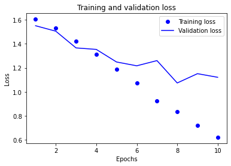

```python
import matplotlib.pyplot as plt
loss = history.history['loss']
val_loss = history.history['val_loss']
epochs = range(1, len(loss) + 1)
plt.plot(epochs, loss, 'bo', label='Training loss')
plt.plot(epochs, val_loss, 'b', label='Validation loss')
plt.title('Training and validation loss')
plt.xlabel('Epochs')
plt.ylabel('Loss')
plt.legend()
plt.show()
```

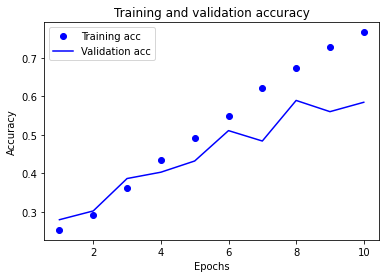

```python
plt.clf()
acc = history.history['accuracy']
val_acc = history.history['val_accuracy']
plt.plot(epochs, acc, 'bo', label='Training acc')
plt.plot(epochs, val_acc, 'b', label='Validation acc')
plt.title('Training and validation accuracy')
plt.xlabel('Epochs')
plt.ylabel('Accuracy')
plt.legend()
plt.show()
```

```python
from sklearn import metrics
from sklearn.metrics import classification_report
y_pred_rnn_one_hot_encoded = (model.predict(padded_test)> 0.5).astype("int32")
y_pred_rnn = np.array(tf.argmax(y_pred_rnn_one_hot_encoded, axis=1))

print(classification_report(y_test, y_pred_rnn))
```

```
              precision    recall  f1-score   support

           0       0.38      0.73      0.50       421
           1       0.54      0.44      0.49       423
           2       0.68      0.69      0.69       396
           3       0.77      0.58      0.66       427
           4       0.78      0.40      0.53       432

    accuracy                           0.57      2099
   macro avg       0.63      0.57      0.57      2099
weighted avg       0.63      0.57      0.57      2099
```

```python
model.save('RNN-Model')
```

[output not shown]

```
INFO:tensorflow:Assets written to: RNN-Model/assets
```

[output not shown]

### HW-4.1.3 Bench-mark-2: 1D-CNN

- Train a 1D-CNN model to predict the novel category labels based on the text
- Try to maximize the validation accuracy by doing manual (or automated) hyper-parameter tuning
  - Do K=1 validation (i.e just one split of training-test-validation)
  - Include some form of regularization (L1, L2, Dropout)
  - Include training history Convergence plots for the validation and training sets
  - report the final training/test/validation accuracy at the end
  - Save your final trained model to a file
- Document your process using markdown between code cells to help external collaborators understand what you are doing.

```python
from keras.layers import Conv1D, MaxPooling1D, Embedding
from keras.regularizers import l2

model = Sequential()
model.add(Embedding(input_dim=vocab_size, output_dim=vector_size, weights=[embedding_matrix], input_length=max_seq_len))
model.add(Conv1D(32, 7, activation='relu'))
model.add(MaxPooling1D(5))
model.add(Conv1D(32, 7, activation='relu'))
model.add(layers.GlobalMaxPooling1D())
model.add(Dense(6, kernel_regularizer=l2(0.01), activation='softmax'))

model.compile(optimizer='rmsprop',loss='categorical_crossentropy',metrics=['accuracy'])
```

```python
history = model.fit(padded_train,
                    train_labels,
                    validation_split=0.2,
                    callbacks=callbacks,
                    epochs=10)
```

```
Epoch 00001: val_loss did not improve from 0.91369
Epoch 00002: val_loss did not improve from 0.91369
Epoch 00003: val_loss did not improve from 0.91369
Epoch 00004: val_loss did not improve from 0.91369
Epoch 00005: val_loss did not improve from 0.91369
Epoch 00006: val_loss did not improve from 0.91369
Epoch 00007: val_loss did not improve from 0.91369

Epoch 00008: val_loss did not improve from 0.91369
Epoch 00008: early stopping
```

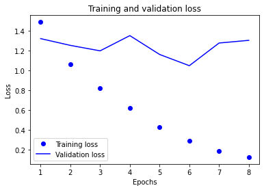

```python
import matplotlib.pyplot as plt
loss = history.history['loss']
val_loss = history.history['val_loss']
epochs = range(1, len(loss) + 1)
plt.plot(epochs, loss, 'bo', label='Training loss')
plt.plot(epochs, val_loss, 'b', label='Validation loss')
plt.title('Training and validation loss')
plt.xlabel('Epochs')
plt.ylabel('Loss')
plt.legend()
plt.show()
```

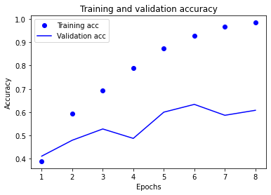

```python
plt.clf()
acc = history.history['accuracy']
val_acc = history.history['val_accuracy']
plt.plot(epochs, acc, 'bo', label='Training acc')
plt.plot(epochs, val_acc, 'b', label='Validation acc')
plt.title('Training and validation accuracy')
plt.xlabel('Epochs')
plt.ylabel('Accuracy')
plt.legend()
plt.show()
```

```python
from sklearn import metrics
from sklearn.metrics import classification_report
y_pred_cnn_one_hot_encoded = (model.predict(padded_test)> 0.5).astype("int32")
y_pred_cnn = np.array(tf.argmax(y_pred_cnn_one_hot_encoded, axis=1))

print(classification_report(y_test, y_pred_cnn))
```

```
              precision    recall  f1-score   support

           0       0.43      0.76      0.55       421
           1       0.51      0.46      0.49       423
           2       0.66      0.64      0.65       396
           3       0.87      0.60      0.71       427
           4       0.73      0.51      0.60       432

    accuracy                           0.59      2099
   macro avg       0.64      0.59      0.60      2099
weighted avg       0.64      0.59      0.60      2099
```

```python
model.save('CONV1D-Model')
```

```
INFO:tensorflow:Assets written to: CONV1D-Model/assets
```

```
INFO:tensorflow:Assets written to: CONV1D-Model/assets
```

### HW-4.1.4 LSTM or GRU models

- Train an LSTM or GRU model to predict the novel category labels based on the text
  - Try to exceed the accuracy of the baseline models
- Try to maximize the validation accuracy by doing manual (or automated) hyper-parameter tuning
  - Do K=1 validation (i.e just one split of training-test-validation)
  - Include some form of regularization (L1, L2, Dropout)
  - Include training history Convergence plots for the validation and training sets
  - report the final training/test/validation accuracy at the end
  - Save your final trained model to a file
- Document your process using markdown between code cells to help external collaborators understand what you are doing.

```python
model = Sequential()
model.add(Embedding(input_dim=vocab_size, output_dim=vector_size, weights=[embedding_matrix], input_length=max_seq_len))
model.add(Dropout(0.6))
model.add(LSTM(max_seq_len,return_sequences=True))
model.add(LSTM(6))
model.add(Dense(6,activation='softmax'))

model.compile(optimizer='rmsprop',loss='categorical_crossentropy',metrics=['accuracy'])
```

```python
history = model.fit(padded_train,
                    train_labels,
                    validation_split=0.2,
                    callbacks=callbacks,
                    epochs=10)
```

```
Epoch 00001: val_loss did not improve from 0.91369
Epoch 00002: val_loss did not improve from 0.91369
Epoch 00003: val_loss did not improve from 0.91369
Epoch 00004: val_loss did not improve from 0.91369
Epoch 00005: val_loss did not improve from 0.91369
Epoch 00006: val_loss did not improve from 0.91369
Epoch 00007: val_loss did not improve from 0.91369
Epoch 00008: val_loss did not improve from 0.91369
Epoch 00009: val_loss did not improve from 0.91369
Epoch 00010: val_loss did not improve from 0.91369
```

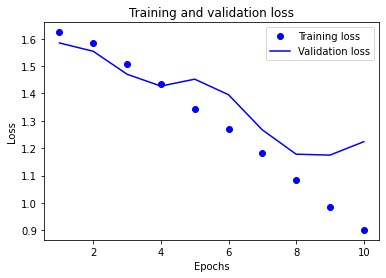

```python
import matplotlib.pyplot as plt
loss = history.history['loss']
val_loss = history.history['val_loss']
epochs = range(1, len(loss) + 1)
plt.plot(epochs, loss, 'bo', label='Training loss')
plt.plot(epochs, val_loss, 'b', label='Validation loss')
plt.title('Training and validation loss')
plt.xlabel('Epochs')
plt.ylabel('Loss')
plt.legend()
plt.show()
```

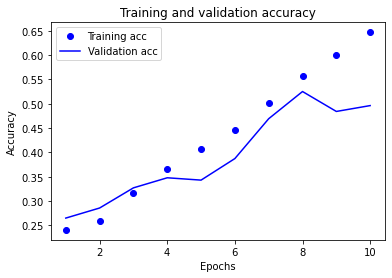

```python
plt.clf()
acc = history.history['accuracy']
val_acc = history.history['val_accuracy']
plt.plot(epochs, acc, 'bo', label='Training acc')
plt.plot(epochs, val_acc, 'b', label='Validation acc')
plt.title('Training and validation accuracy')
plt.xlabel('Epochs')
plt.ylabel('Accuracy')
plt.legend()
plt.show()
```

```python
from sklearn import metrics
from sklearn.metrics import classification_report
y_pred_lstm_one_hot_encoded = (model.predict(padded_test)> 0.5).astype("int32")
y_pred_lstm = np.array(tf.argmax(y_pred_lstm_one_hot_encoded, axis=1))

print(classification_report(y_test, y_pred_lstm))
```

```
              precision    recall  f1-score   support

           0       0.25      0.34      0.29       421
           1       0.44      0.56      0.49       423
           2       0.73      0.26      0.38       396
           3       0.50      0.78      0.60       427
           4       0.79      0.35      0.48       432

    accuracy                           0.46      2099
   macro avg       0.54      0.45      0.45      2099
weighted avg       0.54      0.46      0.45      2099
```

```python
model.save('LSTM-Model')
```

[output not shown]

```
INFO:tensorflow:Assets written to: LSTM-Model/assets
```

[output not shown]